# Amazon Fine Food Reviews Analysis

Data Source: https://www.kaggle.com/snap/amazon-fine-food-reviews

EDA: https://nycdatascience.com/blog/student-works/amazon-fine-foods-visualization/

The Amazon Fine Food Reviews dataset consists of reviews of fine foods from Amazon.

Number of reviews: 568,454  
Number of users: 256,059  
Number of products: 74,258  
Timespan: Oct 1999 - Oct 2012  
Number of Attributes/Columns in data: 10

Attribute Information:

1. Id
2. ProductId - unique identifier for the product
3. UserId - unqiue identifier for the user
4. ProfileName
5. HelpfulnessNumerator - number of users who found the review helpful
6. HelpfulnessDenominator - number of users who indicated whether they found the review helpful or not
7. Score - rating between 1 and 5
8. Time - timestamp for the review
9. Summary - brief summary of the review
10. Text - text of the review

#### Objective:

Given a review, determine whether the review is positive (rating of 4 or 5) or negative (rating of 1 or 2).

[Q] How to determine if a review is positive or negative?  
[Ans] We could use Score/Rating. A rating of 4 or 5 can be cosnidered as a positive review. A rating of 1 or 2 can be considered as negative one. A review of rating 3 is considered nuetral and such reviews are ignored from our analysis. This is an approximate and proxy way of determining the polarity (positivity/negativity) of a review.

# [1]. Reading Data

## [1.1] Loading the data

The dataset is available in two forms

1. .csv file
2. SQLite Database

In order to load the data, We have used the SQLITE dataset as it is easier to query the data and visualise the data efficiently.

Here as we only want to get the global sentiment of the recommendations (positive or negative), we will purposefully ignore all Scores equal to 3. If the score is above 3, then the recommendation wil be set to "positive". Otherwise, it will be set to "negative".

```python
%matplotlib inline
import warnings
warnings.filterwarnings("ignore")


import sqlite3
import pandas as pd
import numpy as np
import nltk
import string
import matplotlib.pyplot as plt
import seaborn as sns
from sklearn.feature_extraction.text import TfidfTransformer
from sklearn.feature_extraction.text import TfidfVectorizer

from sklearn.feature_extraction.text import CountVectorizer
from sklearn.metrics import confusion_matrix
from sklearn import metrics
from sklearn.metrics import roc_curve, auc
from nltk.stem.porter import PorterStemmer

import re
# Tutorial about Python regular expressions: https://pymotw.com/2/re/
import string
from nltk.corpus import stopwords
from nltk.stem import PorterStemmer
from nltk.stem.wordnet import WordNetLemmatizer

from gensim.models import Word2Vec
from gensim.models import KeyedVectors
import pickle

from tqdm import tqdm
import os
```

```python
# using SQLite Table to read data.
con = sqlite3.connect('database.sqlite')

# filtering only positive and negative reviews i.e.
# not taking into consideration those reviews with Score=3
# SELECT * FROM Reviews WHERE Score != 3 LIMIT 500000, will give top 500000 data points
# you can change the number to any other number based on your computing power

# filtered_data = pd.read_sql_query(""" SELECT * FROM Reviews WHERE Score != 3 LIMIT 500000""", con)
# for tsne assignment you can take 5k data points

filtered_data = pd.read_sql_query(""" SELECT * FROM Reviews WHERE Score != 3 LIMIT 100000""", con)

# Give reviews with Score>3 a positive rating(1), and reviews with a score<3 a negative rating(0).
def partition(x):
    if x < 3:
        return 0
    return 1

#changing reviews with score less than 3 to be positive and vice-versa
actualScore = filtered_data['Score']
positiveNegative = actualScore.map(partition)
filtered_data['Score'] = positiveNegative
print("Number of data points in our data", filtered_data.shape)
filtered_data.head(3)
```

```
Number of data points in our data (100000, 10)
```

|  | Id | ProductId | UserId | ProfileName | HelpfulnessNumerator | HelpfulnessDenominator | Score | Time | Summary | Text |
| --- | --- | --- | --- | --- | --- | --- | --- | --- | --- | --- |
| 0 | 1 | B001E4KFG0 | A3SGXH7AUHU8GW | delmartian | 1 | 1 | 1 | 1303862400 | Good Quality Dog Food | I have bought several of the Vitality canned d... |
| 1 | 2 | B00813GRG4 | A1D87F6ZCVE5NK | dll pa | 0 | 0 | 0 | 1346976000 | Not as Advertised | Product arrived labeled as Jumbo Salted Peanut... |
| 2 | 3 | B000LQOCH0 | ABXLMWJIXXAIN | Natalia Corres "Natalia Corres" | 1 | 1 | 1 | 1219017600 | "Delight" says it all | This is a confection that has been around a fe... |

```python
display = pd.read_sql_query("""
SELECT UserId, ProductId, ProfileName, Time, Score, Text, COUNT(*)
FROM Reviews
GROUP BY UserId
HAVING COUNT(*)>1
""", con)
```

```python
print(display.shape)
display.head()
```

```
(80668, 7)
```

|  | UserId | ProductId | ProfileName | Time | Score | Text | COUNT(*) |
| --- | --- | --- | --- | --- | --- | --- | --- |
| 0 | #oc-R115TNMSPFT9I7 | B005ZBZLT4 | Breyton | 1331510400 | 2 | Overall its just OK when considering the price... | 2 |
| 1 | #oc-R11D9D7SHXIJB9 | B005HG9ESG | Louis E. Emory "hoppy" | 1342396800 | 5 | My wife has recurring extreme muscle spasms, u... | 3 |
| 2 | #oc-R11DNU2NBKQ23Z | B005ZBZLT4 | Kim Cieszykowski | 1348531200 | 1 | This coffee is horrible and unfortunately not ... | 2 |
| 3 | #oc-R11O5J5ZVQE25C | B005HG9ESG | Penguin Chick | 1346889600 | 5 | This will be the bottle that you grab from the... | 3 |
| 4 | #oc-R12KPBODL2B5ZD | B007OSBEV0 | Christopher P. Presta | 1348617600 | 1 | I didnt like this coffee. Instead of telling y... | 2 |

```python
display[display['UserId']=='AZY10LLTJ71NX']
```

|  | UserId | ProductId | ProfileName | Time | Score | Text | COUNT(*) |
| --- | --- | --- | --- | --- | --- | --- | --- |
| 80638 | AZY10LLTJ71NX | B001ATMQK2 | undertheshrine "undertheshrine" | 1296691200 | 5 | I bought this 6 pack because for the price tha... | 5 |

```python
display['COUNT(*)'].sum()
```

```
393063
```

# [2] Exploratory Data Analysis

## [2.1] Data Cleaning: Deduplication

It is observed (as shown in the table below) that the reviews data had many duplicate entries. Hence it was necessary to remove duplicates in order to get unbiased results for the analysis of the data. Following is an example:

```python
display= pd.read_sql_query("""
SELECT *
FROM Reviews
WHERE Score != 3 AND UserId="AR5J8UI46CURR"
ORDER BY ProductID
""", con)
display.head()
```

|  | Id | ProductId | UserId | ProfileName | HelpfulnessNumerator | HelpfulnessDenominator | Score | Time | Summary | Text |
| --- | --- | --- | --- | --- | --- | --- | --- | --- | --- | --- |
| 0 | 78445 | B000HDL1RQ | AR5J8UI46CURR | Geetha Krishnan | 2 | 2 | 5 | 1199577600 | LOACKER QUADRATINI VANILLA WAFERS | DELICIOUS WAFERS. I FIND THAT EUROPEAN WAFERS ... |
| 1 | 138317 | B000HDOPYC | AR5J8UI46CURR | Geetha Krishnan | 2 | 2 | 5 | 1199577600 | LOACKER QUADRATINI VANILLA WAFERS | DELICIOUS WAFERS. I FIND THAT EUROPEAN WAFERS ... |
| 2 | 138277 | B000HDOPYM | AR5J8UI46CURR | Geetha Krishnan | 2 | 2 | 5 | 1199577600 | LOACKER QUADRATINI VANILLA WAFERS | DELICIOUS WAFERS. I FIND THAT EUROPEAN WAFERS ... |
| 3 | 73791 | B000HDOPZG | AR5J8UI46CURR | Geetha Krishnan | 2 | 2 | 5 | 1199577600 | LOACKER QUADRATINI VANILLA WAFERS | DELICIOUS WAFERS. I FIND THAT EUROPEAN WAFERS ... |
| 4 | 155049 | B000PAQ75C | AR5J8UI46CURR | Geetha Krishnan | 2 | 2 | 5 | 1199577600 | LOACKER QUADRATINI VANILLA WAFERS | DELICIOUS WAFERS. I FIND THAT EUROPEAN WAFERS ... |

As it can be seen above that same user has multiple reviews with same values for HelpfulnessNumerator, HelpfulnessDenominator, Score, Time, Summary and Text and on doing analysis it was found that  
ProductId=B000HDOPZG was Loacker Quadratini Vanilla Wafer Cookies, 8.82-Ounce Packages (Pack of 8)  
ProductId=B000HDL1RQ was Loacker Quadratini Lemon Wafer Cookies, 8.82-Ounce Packages (Pack of 8) and so on

It was inferred after analysis that reviews with same parameters other than ProductId belonged to the same product just having different flavour or quantity. Hence in order to reduce redundancy it was decided to eliminate the rows having same parameters.

The method used for the same was that we first sort the data according to ProductId and then just keep the first similar product review and delelte the others. for eg. in the above just the review for ProductId=B000HDL1RQ remains. This method ensures that there is only one representative for each product and deduplication without sorting would lead to possibility of different representatives still existing for the same product.

```python
#Sorting data according to ProductId in ascending order
sorted_data=filtered_data.sort_values('ProductId', axis=0, ascending=True, inplace=False, kind='quicksort', na_position='last')
```

```python
#Deduplication of entries
final=sorted_data.drop_duplicates(subset={"UserId","ProfileName","Time","Text"}, keep='first', inplace=False)
final.shape
```

```
(87775, 10)
```

```python
#Checking to see how much % of data still remains
(final['Id'].size*1.0)/(filtered_data['Id'].size*1.0)*100
```

```
87.775
```

**Observation:-** It was also seen that in two rows given below the value of HelpfulnessNumerator is greater than HelpfulnessDenominator which is not practically possible hence these two rows too are removed from calcualtions

```python
display= pd.read_sql_query("""
SELECT *
FROM Reviews
WHERE Score != 3 AND Id=44737 OR Id=64422
ORDER BY ProductID
""", con)

display.head()
```

|  | Id | ProductId | UserId | ProfileName | HelpfulnessNumerator | HelpfulnessDenominator | Score | Time | Summary | Text |
| --- | --- | --- | --- | --- | --- | --- | --- | --- | --- | --- |
| 0 | 64422 | B000MIDROQ | A161DK06JJMCYF | J. E. Stephens "Jeanne" | 3 | 1 | 5 | 1224892800 | Bought This for My Son at College | My son loves spaghetti so I didn't hesitate or... |
| 1 | 44737 | B001EQ55RW | A2V0I904FH7ABY | Ram | 3 | 2 | 4 | 1212883200 | Pure cocoa taste with crunchy almonds inside | It was almost a 'love at first bite' - the per... |

```python
final=final[final.HelpfulnessNumerator<=final.HelpfulnessDenominator]
```

```python
#Before starting the next phase of preprocessing lets see the number of entries left
print(final.shape)

#How many positive and negative reviews are present in our dataset?
final['Score'].value_counts()
```

```
(87773, 10)
```

```
1    73592
0    14181
Name: Score, dtype: int64
```

# [3] Preprocessing

## [3.1]. Preprocessing Review Text

Now that we have finished deduplication our data requires some preprocessing before we go on further with analysis and making the prediction model.

After which we collect the words used to describe positive and negative reviews

```python
# printing some random reviews
sent_0 = final['Text'].values[0]
print(sent_0)
print("="*50)

sent_1000 = final['Text'].values[1000]
print(sent_1000)
print("="*50)

sent_1500 = final['Text'].values[1500]
print(sent_1500)
print("="*50)

sent_4900 = final['Text'].values[4900]
print(sent_4900)
print("="*50)
```

```
My dogs loves this chicken but its a product from China, so we wont be buying it anymore.  Its very hard to find any chicken products made in the USA but they are out there, but this one isnt.  Its too bad too because its a good product but I wont take any chances till they know what is going on wit…
==================================================
The Candy Blocks were a nice visual for the Lego Birthday party but the candy has little taste to it.  Very little of the 2 lbs that I bought were eaten and I threw the rest away.  I would not buy the candy again.
==================================================
was way to hot for my blood, took a bite and did a jig  lol
==================================================
My dog LOVES these treats. They tend to have a very strong fish oil smell. So if you are afraid of the fishy smell, don't get it. But I think my dog likes it because of the smell. These treats are really small in size. They are great for training. You can give your dog several of these without worry…
==================================================
```

```python
# remove urls from text python: https://stackoverflow.com/a/40823105/4084039
sent_0 = re.sub(r"http\S+", "", sent_0)
sent_1000 = re.sub(r"http\S+", "", sent_1000)
sent_150 = re.sub(r"http\S+", "", sent_1500)
sent_4900 = re.sub(r"http\S+", "", sent_4900)

print(sent_0)
```

```
My dogs loves this chicken but its a product from China, so we wont be buying it anymore.  Its very hard to find any chicken products made in the USA but they are out there, but this one isnt.  Its too bad too because its a good product but I wont take any chances till they know what is going on wit…
```

```python
# https://stackoverflow.com/questions/16206380/python-beautifulsoup-how-to-remove-all-tags-from-an-element
from bs4 import BeautifulSoup

soup = BeautifulSoup(sent_0, 'lxml')
text = soup.get_text()
print(text)
print("="*50)

soup = BeautifulSoup(sent_1000, 'lxml')
text = soup.get_text()
print(text)
print("="*50)

soup = BeautifulSoup(sent_1500, 'lxml')
text = soup.get_text()
print(text)
print("="*50)

soup = BeautifulSoup(sent_4900, 'lxml')
text = soup.get_text()
print(text)
```

```
My dogs loves this chicken but its a product from China, so we wont be buying it anymore.  Its very hard to find any chicken products made in the USA but they are out there, but this one isnt.  Its too bad too because its a good product but I wont take any chances till they know what is going on wit…
==================================================
The Candy Blocks were a nice visual for the Lego Birthday party but the candy has little taste to it.  Very little of the 2 lbs that I bought were eaten and I threw the rest away.  I would not buy the candy again.
==================================================
was way to hot for my blood, took a bite and did a jig  lol
==================================================
My dog LOVES these treats. They tend to have a very strong fish oil smell. So if you are afraid of the fishy smell, don't get it. But I think my dog likes it because of the smell. These treats are really small in size. They are great for training. You can give your dog several of these without worry…
```

```python
# https://stackoverflow.com/a/47091490/4084039
import re

def decontracted(phrase):
    # specific
    phrase = re.sub(r"won't", "will not", phrase)
    phrase = re.sub(r"can\'t", "can not", phrase)

    # general
    phrase = re.sub(r"n\'t", " not", phrase)
    phrase = re.sub(r"\'re", " are", phrase)
    phrase = re.sub(r"\'s", " is", phrase)
    phrase = re.sub(r"\'d", " would", phrase)
    phrase = re.sub(r"\'ll", " will", phrase)
    phrase = re.sub(r"\'t", " not", phrase)
    phrase = re.sub(r"\'ve", " have", phrase)
    phrase = re.sub(r"\'m", " am", phrase)
    return phrase
```

```python
sent_1500 = decontracted(sent_1500)
print(sent_1500)
print("="*50)
```

```
was way to hot for my blood, took a bite and did a jig  lol
==================================================
```

```python
#remove words with numbers python: https://stackoverflow.com/a/18082370/4084039
sent_0 = re.sub("\S*\d\S*", "", sent_0).strip()
print(sent_0)
```

```
My dogs loves this chicken but its a product from China, so we wont be buying it anymore.  Its very hard to find any chicken products made in the USA but they are out there, but this one isnt.  Its too bad too because its a good product but I wont take any chances till they know what is going on wit…
```

```python
#remove spacial character: https://stackoverflow.com/a/5843547/4084039
sent_1500 = re.sub('[^A-Za-z0-9]+', ' ', sent_1500)
print(sent_1500)
```

```
was way to hot for my blood took a bite and did a jig lol
```

```python
# https://gist.github.com/sebleier/554280
# we are removing the words from the stop words list: 'no', 'nor', 'not'
# <br /><br /> ==> after the above steps, we are getting "br br"
# we are including them into stop words list
# instead of <br /> if we have <br/> these tags would have revmoved in the 1st step

stopwords= set(['br', 'the', 'i', 'me', 'my', 'myself', 'we', 'our', 'ours', 'ourselves', 'you', "you're", "you've",\
            "you'll", "you'd", 'your', 'yours', 'yourself', 'yourselves', 'he', 'him', 'his', 'himself', \
            'she', "she's", 'her', 'hers', 'herself', 'it', "it's", 'its', 'itself', 'they', 'them', 'their',\
            'theirs', 'themselves', 'what', 'which', 'who', 'whom', 'this', 'that', "that'll", 'these', 'those', \
            'am', 'is', 'are', 'was', 'were', 'be', 'been', 'being', 'have', 'has', 'had', 'having', 'do', 'does', \
            'did', 'doing', 'a', 'an', 'the', 'and', 'but', 'if', 'or', 'because', 'as', 'until', 'while', 'of', \
            'at', 'by', 'for', 'with', 'about', 'against', 'between', 'into', 'through', 'during', 'before', 'after',\
            'above', 'below', 'to', 'from', 'up', 'down', 'in', 'out', 'on', 'off', 'over', 'under', 'again', 'further',\
            'then', 'once', 'here', 'there', 'when', 'where', 'why', 'how', 'all', 'any', 'both', 'each', 'few', 'more',\
            'most', 'other', 'some', 'such', 'only', 'own', 'same', 'so', 'than', 'too', 'very', \
            's', 't', 'can', 'will', 'just', 'don', "don't", 'should', "should've", 'now', 'd', 'll', 'm', 'o', 're', \
            've', 'y', 'ain', 'aren', "aren't", 'couldn', "couldn't", 'didn', "didn't", 'doesn', "doesn't", 'hadn',\
            "hadn't", 'hasn', "hasn't", 'haven', "haven't", 'isn', "isn't", 'ma', 'mightn', "mightn't", 'mustn',\
            "mustn't", 'needn', "needn't", 'shan', "shan't", 'shouldn', "shouldn't", 'wasn', "wasn't", 'weren', "weren't", \
            'won', "won't", 'wouldn', "wouldn't"])
```

```python
# Combining all the above stundents
from tqdm import tqdm
preprocessed_reviews = []
# tqdm is for printing the status bar
for sentance in tqdm(final['Text'].values):
    sentance = re.sub(r"http\S+", "", sentance)
    sentance = BeautifulSoup(sentance, 'lxml').get_text()
    sentance = decontracted(sentance)
    sentance = re.sub("\S*\d\S*", "", sentance).strip()
    sentance = re.sub('[^A-Za-z]+', ' ', sentance)
    # https://gist.github.com/sebleier/554280
    sentance = ' '.join(e.lower() for e in sentance.split() if e.lower() not in stopwords)
    preprocessed_reviews.append(sentance.strip())
```

```python
preprocessed_reviews[1500]
```

```
'way hot blood took bite jig lol'
```

# [4] Featurization

## taking top 2000 feartures based on idf values

```python
tfidf = TfidfVectorizer(min_df=10)
X=tfidf.fit_transform(preprocessed_reviews)
idf=tfidf.idf_
idflist=list(idf)
```

```python
import numpy as np
sort_idf=np.argsort(idflist)
```

```python
feat=tfidf.get_feature_names()
```

```python
r=[]
for i in range(0,2000):
  r.append(feat[sort_idf[i]])
```

```python
r[1]
```

```
'like'
```

# [5] Assignment 11: Truncated SVD

1. **Apply Truncated-SVD on only this feature set:**
   - SET 2:Review text, preprocessed one converted into vectors using (TFIDF)
   - **Procedure:**
     - Take top 2000 or 3000 features from tf-idf vectorizers using idf_ score.
     - You need to calculate the co-occurrence matrix with the selected features (Note: X.X^T doesn’t give the co-occurrence matrix, it returns the covariance matrix, check these bolgs [blog-1,](https://medium.com/data-science-group-iitr/word-embedding-2d05d270b285) [blog-2](https://www.analyticsvidhya.com/blog/2017/06/word-embeddings-count-word2veec/) for more information)
     - You should choose the n_components in truncated svd, with maximum explained variance. Please search on how to choose that and implement them. (hint: plot of cumulative explained variance ratio)
     - After you are done with the truncated svd, you can apply K-Means clustering and choose the best number of clusters based on elbow method.
     - Print out wordclouds for each cluster, similar to that in previous assignment.
     - You need to write a function that takes a word and returns the most similar words using cosine similarity between the vectors(vector: a row in the matrix after truncatedSVD)

## checking on toy data

```python
a=[['abc','def','ijk','pqr'],['pqr','klm','opq'],['lmn','pqr','xyz','abc','def','pqr','abc']]
r1=['abc','pqr','def']
import numpy as np
t = np.zeros((len(r1),len(r1)))
for wrd in a:
    for i in range(len(wrd)):
        if wrd[i] in r1:
            p=r1.index(wrd[i])
            if i < (len(wrd)-2):
                if wrd[i+1] in r1:
                    t[p][r1.index(wrd[i+1])]+=1
                    t[r1.index(wrd[i+1])][p]+=1
                if wrd[i+2] in r1:
                    t[p][r1.index(wrd[i+2])]+=1
                    t[r1.index(wrd[i+2])][p]+=1
            if i == (len(wrd)-2):
                if wrd[i+1] in r1:
                    t[p][r1.index(wrd[i+1])]+=1
                    t[r1.index(wrd[i+1])][p]+=1
```

```python
t
```

```
array([[0., 3., 3.],
       [3., 0., 2.],
       [3., 2., 0.]])
```

# now making truncated svd on tfidf

```python
t = np.zeros((len(r),len(r)))
```

```python
for sent in preprocessed_reviews:
    wrd = sent.split()
    for i in range(len(wrd)):
        if wrd[i] in r:
            p=r.index(wrd[i])
            if i < (len(wrd)-2):
                if wrd[i+1] in r:
                    t[p][r.index(wrd[i+1])]+=1
                    t[r.index(wrd[i+1])][p]+=1
                if wrd[i+2] in r:
                    t[p][r.index(wrd[i+2])]+=1
                    t[r.index(wrd[i+2])][p]+=1
            if i == (len(wrd)-2):
                if wrd[i+1] in r:
                    t[p][r.index(wrd[i+1])]+=1
                    t[r.index(wrd[i+1])][p]+=1
```

### [5.3] Finding optimal value for number of components (n) to be retained.

```python
# Please write all the code with proper documentation
from sklearn.decomposition import TruncatedSVD
comp=[10,30,50,100,150,200,300,500,1000]
var=[]
for i in comp:
    svd = TruncatedSVD(n_components=i, n_iter=7, random_state=42).fit(t)
    per_var=svd.explained_variance_ratio_
    var_sum=sum(per_var)
    var.append(var_sum)
```

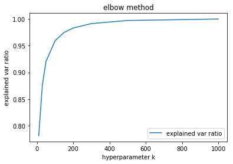

```python
plt.title("elbow method")
plt.plot(comp,var,label="explained var ratio")
plt.xlabel("hyperparameter k")
plt.ylabel("explained var ratio")
plt.legend()
plt.show()
```

```python
svd = TruncatedSVD(n_components=200, n_iter=7, random_state=42).fit_transform(t)
```

```python
tsv=[]
for i in svd:
    wrd = list(i)
    tsv.append(wrd)
```

```python
len(tsv[0])
```

```
200
```

```python
len(r[1])
```

```
4
```

```python
dictonary = dict(zip(r, tsv))
```

```python
sent_vectors = []; # the avg-w2v for each sentence/review is stored in this list
for sent in tqdm(preprocessed_reviews): # for each review/sentence
    sent_vec = np.zeros(200) # as word vectors are of zero length 200, you might need to change this to 300 if you use google's w2v
    cnt_words =0; # num of words with a valid vector in the sentence/review
    wrd = sent.split()
    for word in wrd: # for each word in a review/sentence
        if word in r:
            vec = dictonary.get(word)
            sent_vec += vec
            cnt_words += 1
    if cnt_words != 0:
        sent_vec /= cnt_words
    sent_vectors.append(sent_vec)
print(len(sent_vectors))
print(len(sent_vectors[0]))
```

```
87773
200
```

```python
sent_vectors[1]
```

```
array([ 7.84509588e+02, -1.96744036e+01, -2.09356951e+02,  5.15119637e+01,
       -1.95874771e+02, -7.04178161e-02,  1.17830436e+02,  1.60240602e+01,
       -3.69350820e+00, -1.29375639e+02,  1.61227622e+02, -8.37179072e+01,
       -3.13555515e+01, -9.16588047e+01,  9.79082733e+01,  1.69297491e+00,
       -2.05380635e+01,  6.86586282e+00, -2.12101740e+01, -6.89736884e+01,
       -4.59328210e+01,  8.13056041e+01,  1.88808977e+02,  1.13849127e+02,
        1.20301457e+02,  1.78977073e+01,  4.80360714e+01, -4.84360592e+01,
        1.38235127e+01,  2.29496458e-01,  3.18586751e+01,  1.95932219e+01,
        2.11758429e+01, -1.32079109e+01, -8.08891216e+01,  1.84973608e+01,
        7.63324950e+00, -5.00047279e+01, -1.32798248e+01,  7.79577536e+00,
        8.23590099e+00, -6.55017270e+00, -3.34024992e+01,  6.40789222e+00,
       -3.41358956e+01,  1.20376728e+01, -9.84096592e+00, -1.37361573e+01,
       -1.53872511e+01, -2.70665164e+01,  6.30619097e+00,  2.41503073e+00,
        1.65868573e+01, -5.70150973e+00, -4.92602168e-01, -2.15212784e+01,
        5.53550415e-01,  7.95579384e+00, -1.46727330e+00,  5.18749776e+00,
       -8.11694685e+00, -8.91104062e+00,  4.70309491e+00,  2.86601223e+00,
       -2.16762367e+01,  5.47434710e+00, -4.07005014e+00, -1.31440707e+01,
        8.90686569e+00,  9.89274453e-01,  3.48603741e+00, -9.41185314e+00,
        5.27376797e+00,  1.37792844e+00,  7.50412650e-01,  1.65683365e+01,
       -6.96174949e+00, -9.93354694e+00, -9.71649513e-01,  2.15783447e+01,
       -9.29116964e+00, -7.46784351e+00, -1.14124440e+01,  1.36174887e+01,
        4.83052298e+00, -7.67942425e+00, -9.69800884e-01,  8.87183040e+00,
       -1.12322696e+01, -9.37000548e+00, -6.89191820e-01,  1.32865481e+01,
       -7.27920970e+00, -7.16495431e-02,  1.06063173e+00,  1.13006701e+01,
        2.37707429e+00, -4.11782473e+00,  2.78277528e+00, -4.23418897e-01,
       -5.25053492e-01,  1.26765490e+01,  5.46250627e+00,  8.17595871e-01,
       -7.07277569e+00, -3.51324888e+00, -7.17136384e+00, -3.05324681e+00,
       -1.76913959e+01, -1.08954982e+01,  2.29398831e+00,  1.84903465e+00,
        6.14265360e+00, -1.87216388e+01,  1.02945824e+01,  1.01890438e+01,
       -4.89145375e+00, -1.04821909e+01, -1.18219816e+01, -3.91593667e+00,
        9.47618734e+00, -1.46216660e-01, -2.64495520e+00, -1.65962454e+01,
        4.06897336e+00, -1.24616440e+01, -1.85759042e-01,  1.63634518e+00,
        2.28526316e+00,  4.18755734e+00,  9.22460544e+00,  1.03407064e+00,
       -1.45823661e+01,  1.40393011e+00, -1.61544370e+01,  5.84923050e+00,
       -8.39893460e+00,  1.07746027e+01,  2.81867475e+00, -5.86304380e+00,
       -7.26524284e+00, -2.79954921e+00, -1.23598659e+00, -3.89777967e+00,
        5.57927933e-01,  5.82115555e+00, -1.32782373e+00, -2.34325682e+00,
        2.15247341e+01,  2.64714306e+00, -6.21446097e+00,  1.24528470e+01,
        7.04594640e+00, -4.36987816e+00, -6.75644742e-01, -8.20969397e+00,
       -2.47842660e+00, -1.36404272e+00,  1.17336592e+00,  3.49537558e+00,
        9.89746169e+00, -1.00880168e+01,  5.14794150e+00, -3.23130331e+00,
       -3.04441718e+00,  7.11974393e-01,  1.92057196e+00, -8.22119383e+00,
        2.04005063e+00, -2.74411430e+00,  4.55339143e+00,  5.22104483e+00,
       -7.87106261e-01,  6.03857021e+00, -1.10997349e+00, -2.21551215e+00,
        7.54566739e+00, -6.55445632e+00,  6.54435025e-01, -2.35291232e+00,
       -7.67474824e-01,  5.41794108e+00, -7.29996583e+00, -9.31805682e+00,
        3.68637467e+00, -4.26886215e+00,  2.05098787e-01, -4.11108412e+00,
        7.18741995e-01,  2.90916862e+00,  2.74040104e+00, -5.66711404e+00,
        1.56585419e+00,  2.76919836e+00, -1.54933759e+00,  9.80626974e-01,
        3.07418605e+00, -1.06850802e+00,  1.17299404e+00,  2.89252529e+00])
```

### [5.4] Applying k-means clustering

```python
# Please write all the code with proper documentation
from sklearn.cluster import KMeans
dist=[]
K=[1,2,3,4,5,6,7,8]
for i in K:
     kmeans = KMeans(n_clusters=i, random_state=0).fit(sent_vectors)
     dist.append(kmeans.inertia_)
```

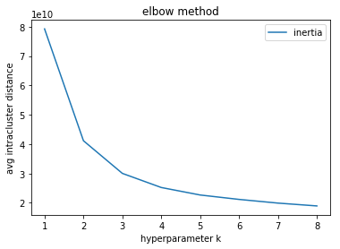

```python
plt.title("elbow method")
plt.plot(K,dist,label="inertia")
plt.xlabel("hyperparameter k")
plt.ylabel("avg intracluster distance")
plt.legend()
plt.show()
```

```python
kmeans = KMeans(n_clusters=2, random_state=0).fit(svd)
label=kmeans.labels_
```

### [5.5] Wordclouds of clusters obtained in the above section

```python
from wordcloud import WordCloud
def plot_wordcloud(reviews):
    wordcloud = WordCloud(width = 600, height = 600,
                background_color ='white',
                min_font_size = 10).generate(str(reviews))

    return wordcloud
```

```
Cluster 0
```

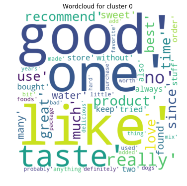

```
Cluster 1
```

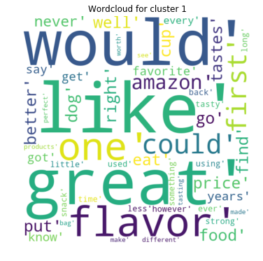

```python
from wordcloud import WordCloud, STOPWORDS

stopwords_t = set(STOPWORDS)

centroids = kmeans.cluster_centers_.argsort()


reviews = []

for i in range(2):
    print("Cluster {}".format(i))
    for j in centroids[i, :50]: # This takes top 50 words of each cluster.
        reviews.append(r[j])
    wc = plot_wordcloud(reviews)
    fig = plt.figure(figsize=(6,6))
    plt.imshow(wc, interpolation='bilinear')
    plt.axis("off")
    plt.title("Wordcloud for cluster {}".format(i))
    plt.show()
    reviews.clear()
```

### [5.6] Function that returns most similar words for a given word.

```python
from scipy.spatial import distance
import numpy as np

def sim(word,no):
    dist=np.random.rand(2000)
    idx=r.index(word)
    for i in range(2000):
        dst = distance.euclidean(svd[i],svd[idx])
        dist[i]=(dst)
    d=dist.argsort()
    for i in range(1,no+1):
        print(r[d[i]])
```

```python
sim('like',5)
```

```
good
taste
flavor
would
great
```

# [6] Conclusions

Please write down few lines about what you observed from this assignment.

Also please do mention the optimal values that you obtained for number of components & number of clusters.

FIRST I TRIED COOCCURENCE MATRIX CONSTRUCTION BY SEARCHING WHOLE REVIEWS FOR A WORD .THIS WAS TIME TAKING;

THEN I PLACED ALL REVIEWS IN A SINGLE LIST AND SEARCH LIST TO FIND COOCCURENCE MATRIX JUST ONCE WHICH WAS FAST.

THE OPTIMAL NO OF CLUSTER WAS 2 AND NO OF COMPONENTS WERE 200.